# Shiny

9 Décembre 2019

## Diapositives et matériel

### mcanouil/rshiny

## Préparer sa session

## Trucs et astuces

- Eviter de changer votre répertoire de travail avec `setwd()`.
- Ne pas utiliser de `.Rprofile` modifiant .
- Désactiver la conversion automatique en facteurs `options(stringsAsFactors = FALSE)`.
- Ne pas utiliser `rm(list = ls())` pour “rafraichir”.
- Ne pas utiliser la sauvegarde/restauration par défaut de .

[figure not shown]

[figure not shown]

## Qu’est-ce que *Shiny* ?

## Avant *Shiny* …

Il était nécessaire de connaître/maîtriser :

- **HTML**, pour concevoir des pages (statique) web.
- **CSS**, pour ajouter du *style* à une page HTML.
- **JavaScript**, pour effectuer des “calculs” au sein d’une page HTML (via un navigateur).

## *Shiny*

Shiny est une extension permettant la création d’application web interactive directement depuis .

- Page internet.
- Documents (R Markdown) interactifs.
- Tableaux de bords.

Les applications Shiny sont compatibles avec :

- CSS.
- “html widgets”.
- JavaScript.

## Installation & Chargement

La version stable de Shiny peut se télécharger sur le CRAN.

```r
install.packages("shiny")
```

La version en développement est disponible sur GitHub .

```r
if (!require("remotes")) install.packages("remotes")
remotes::install_github("rstudio/shiny")
```

Charger Shiny dans sa session .

```r
library("shiny")
```

## Composantes d’une application *Shiny*

- L’extension Shiny.

  ```r
  library("shiny")
  ```

- Une interface (`ui`, *i.e.*, “user interface”).

  ```r
  ui <- fluidPage("Bonjour, vous êtes sur une application Shiny !")
  ```

- Une fonction serveur (`server`).

  ```r
  server <- function(input, output, session) { }
  ```

- La construction d’un objet “Shiny app”.

  ```r
  shinyApp(ui, server)
  ```

## Composantes d’une application *Shiny*

L’application Shiny peut être démarrée par simple exécution.

```r
library("shiny")

ui <- fluidPage("Bonjour, vous êtes sur une application Shiny !")

server <- function(input, output, session) { }

shinyApp(ui, server)
```

## Composantes d’une application *Shiny*

Ou via un script `app.R`, placé dans un répertoire portant généralement le nom de l’application.

```
materials/00-app
└── app.R
```

```r
library("shiny")

ui <- fluidPage("Bonjour, vous êtes sur une application Shiny !")

server <- function(input, output, session) { }

shinyApp(ui, server)
```

```r
runApp("materials/00-app")
```

## Composantes d’une application *Shiny*

Une fois l’application démarrée, vous devriez voir une fenêtre s’ouvrir.

```r
runApp("materials/00-app")
```

```
#> Listening on http://127.0.0.1:4550
```

## L’interface (`ui`)

Pour ajouter des contrôles (`*Input()`).

```r
ui <- fluidPage("Bonjour, vous êtes sur une application Shiny !")
```

```r
ui <- fluidPage(
  textInput(inputId = "name", label = "Nom", value = "default")
)
```

## L’interface (`ui`)

Pour ajouter des contrôles (`*Input()`).

```r
ui <- fluidPage("Bonjour, vous êtes sur une application Shiny !")
```

```r
ui <- fluidPage(
  textInput(inputId = "name", label = "Nom", value = "default")
)
```

- `fluidPage()`, la fonction gérant la structure de la page internet (“responsive web design”).

## L’interface (`ui`)

Pour ajouter des contrôles (`*Input()`).

```r
ui <- fluidPage("Bonjour, vous êtes sur une application Shiny !")
```

```r
ui <- fluidPage(
  textInput(inputId = "name", label = "Nom", value = "default")
)
```

- `textInput()`, la fonction gérant un champ de saisie de texte.

## L’interface (`ui`)

Les contrôles (`*Input()`) nativement disponibles :

- `checkboxGroupInput()`
- `checkboxInput()`
- `dateInput()`
- `dateRangeInput()`
- `fileInput()`
- `numericInput()`
- `passwordInput()`
- `selectInput()`
- `selectizeInput()`
- `sliderInput()`
- `textAreaInput()`
- `textInput()`

## L’interface (`ui`)

```r
runApp("materials/01-app")
```

```
#> Listening on http://127.0.0.1:4550
```

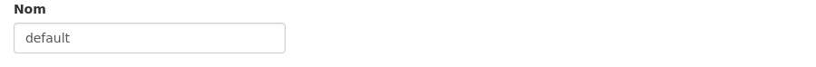

## Le serveur (`server`)

Notre application ne contient aucune action serveur (`server`).

```r
library("shiny")

ui <- fluidPage(
  textInput(inputId = "name", label = "Nom", value = "default")
)

server <- function(input, output, session) { }

shinyApp(ui, server)
```

## Le serveur (`server`)

- Du `server` à `ui` \(\rightarrow\) `output`.

```r
server <- function(input, output, session) {
  output$hello_message <- renderText("Bonjour")
}
```

```r
output$id <- renderTYPE({
  # Une expression générant la sortie de type "TYPE"
})
```

- Partie *gauche* : objet (`output`) renvoyé vers l’interface (`ui`) avec un identifiant unique (`id`).
- Partie *droite* : fonction spécifique pour générer la sortie qui pourra être affichée dans l’interface (`ui`).

## Le serveur (`server`)

Les fonctions `render*()` nativement disponibles :

- `renderCachedPlot()`
- `renderDataTable()`
- `renderImage()`
- `renderPlot()`
- `renderPrint()`
- `renderTable()`
- `renderText()`
- `renderUI()`

## Le serveur (`server`)

- Du `server` à `ui` \(\rightarrow\) `output`.

```r
server <- function(input, output, session) {
  output$hello_message <- renderText("Bonjour")
}
```

- `textOutput()`, la fonction gérant l’affichage des éléments construits par le serveur (`server`).

```r
ui <- fluidPage(
  textInput(inputId = "name", label = "Nom", value = "default"),
  textOutput(outputId = "hello_message")
)
```

## Première application *Shiny*

```r
library("shiny")

ui <- fluidPage(
  textInput(inputId = "name", label = "Nom", value = "default"),
  textOutput(outputId = "hello_message")
)

server <- function(input, output, session) {
  output$hello_message <- renderText("Bonjour")
}

shinyApp(ui, server)
```

## Première application *Shiny*

```r
runApp("materials/02-app")
```

```
#> Listening on http://127.0.0.1:4550
```

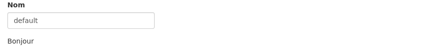

## *Shiny*

### Les entrées `input`

## Les `input` en détails

```r
  textInput(inputId = "name", label = "Nom", value = "default"),
```

Contraintes sur les valeurs de `inputID` :

- Doit être unique.
- Chaîne de caractères alphanumériques et “underscores”.

## `input` de type texte

```r
ui <- fluidPage(
  textInput("name", "Nom"),
  passwordInput("password", "Mot de passe"),
  textAreaInput("description", "Description", rows = 3)
)
```

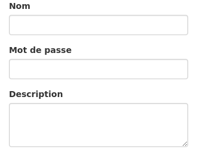

## `input` de type numérique

```r
ui <- fluidPage(
  numericInput("num1", "Nombre 1", value = 0, min = 0, max = 100),
  sliderInput("num2", "Nombre 2", value = 42, min = 0, max = 100),
  sliderInput("rng", "Gamme", value = c(7, 42), min = 0, max = 100)
)
```

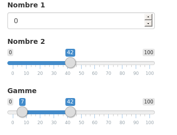

## `input` de type date

```r
ui <- fluidPage(
  dateInput("uniq_date", "Date unique"),
  dateRangeInput("period", "Période")
)
```

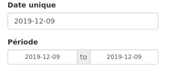

## `input` de sélection simple

```r
ui <- fluidPage(
  selectInput("letters", "Lettres minuscules", head(letters)),
  radioButtons("letters2", "Lettres majuscules", LETTERS[1:5])
)
```

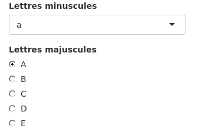

## `input` de sélection multiple

```r
ui <- fluidPage(
  checkboxInput(
    "bin1", 'Question binaire ("oui" par défaut)', value = TRUE
  ),
  checkboxInput("bin2", 'Question binaire ("non" par défaut)'),
  checkboxGroupInput("letters3", "Plusieurs Lettres", LETTERS[5:1])
)
```

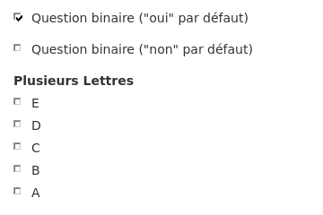

## `input` d’action

```r
ui <- fluidPage(
  fileInput("upload", NULL),
  actionButton("click", "Cliquez ici !", icon = icon("mouse-pointer")),
  p( actionLink("click", "Cliquez ici !", icon = icon("home")) )
)
```

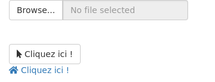

*Note : `icon()` utilise la bibliothèque d’icônes [Font Awesome](https://fontawesome.com/).*

## Mise en pratique

- Essayez les différents `input` en jouant sur les arguments.
- Créez un fomulaire : nom, prénom, age, sexe, loisirs (choix multiples).

## Mise en pratique

- Créez un fomulaire : nom, prénom, age, sexe, loisirs (choix multiples).

```r
ui <- fluidPage(
  textInput("lastname", "Nom", value = ""),
  textInput("firstname", "Prénom", value = ""),
  numericInput("age", "Age", value = 0),
  radioButtons("sex", "Sexe",
    choices = c("Femme", "Homme", "Ne sait pas"),
    selected = "Ne sait pas"
  ),
  checkboxGroupInput("hobbies", "Loisirs",
    choices = c("Vélo", "Rando", "Natation", "Badminton", "Autres")
  )
)
```

## Mise en pratique

- Créez un fomulaire : nom, prénom, age, sexe, loisirs (choix multiples).

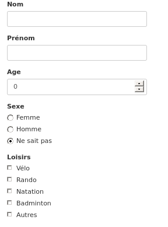

## *Shiny*

### Les sorties `output`

## Les `output` en détails

```r
  textOutput(outputId = "hello_message")
```

Contraintes sur les valeurs de `outputId` :

- Doit être unique.
- Chaîne de caractères alphanumériques et “underscores”.

## `output` de type texte

```r
library("shiny")

ui <- fluidPage(
  textOutput("text"),
  verbatimTextOutput("code")
)

server <- function(input, output, session) {
  output$text <- renderText({
    "Bonjour, vous êtes sur une application Shiny !"
  })
  output$code <- renderPrint({
    summary(rnorm(10))
  })
}

shinyApp(ui, server)
```

## `output` de type texte

```r
ui <- fluidPage(
  textOutput("text"),
  verbatimTextOutput("code")
)
server <- function(input, output, session) {
  output$text <- renderText({
    "Bonjour, vous êtes sur une application Shiny !"
  })
  output$code <- renderPrint({
    summary(rnorm(10))
  })
}
```

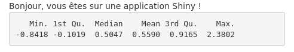

## `output` de type texte

```r
ui <- fluidPage(
  textOutput("text"),
  textOutput("code")
)
server <- function(input, output, session) {
  output$text <- renderText({
    "Du texte"
  })
  output$code <- renderPrint({
    "Du code"
  })
}
```

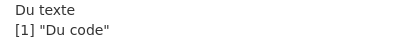

## `output` de type texte

```r
ui <- fluidPage(
  verbatimTextOutput("text"),
  verbatimTextOutput("code")
)

server <- function(input, output, session) {
  output$text <- renderText({ summary(rnorm(10)) })
  output$code <- renderPrint({ summary(rnorm(10)) })
}
```

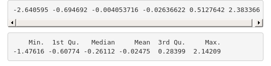